# Censored Data with Hierarchical Model

Langyan Zang

03 August, 2022

## Censored Data Analysis

The data in wtp_data.csv represent the amounts two groups of participants (A and B) are willing to pay for snack food items. Each individual placed bids to buy 60 different foods. All participants saw the same 60 foods. They were given an endowment of 5 CHF per food item to use in purchasing the foods from the experimenter. Thus, the maximum bid was 5, even if the participant might have been willing to pay more than 5 CHF.

> *Analysis Design:* Test whether Group A and Group B differ in terms of the amount that they bid to purchase snack food items using a standard normal model and a normal model including censor limits at 0 and 5 CHF. Both the standard normal and censored normal models are hierarchical.

### Density plot for both groups

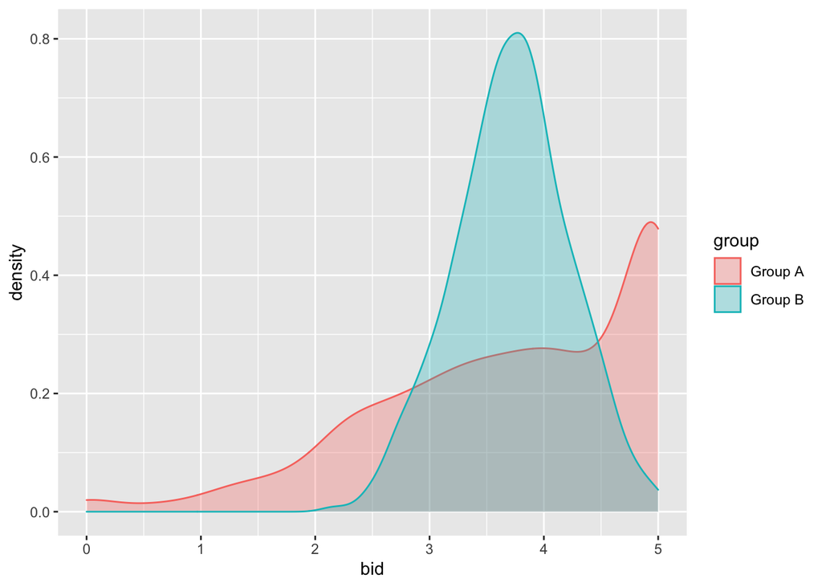

```r
data <- read.csv("data/wtp_data.csv",stringsAsFactors = TRUE)
# prepare data.frame for plot
df_plot <- data.frame(
    bid=c(data$Bid[which(data$Group=="A")],data$Bid[which(data$Group=="B")]),
    group=rep(c("Group A", "Group B"), each=length(data$Bid[which(data$Group=="A")]) )
    )
ggplot(df_plot, aes(x=bid, color=group, fill=group)) + geom_density(alpha=0.3)
```

### Standard normal model and Censored normal model

```r
# bid data
y <- data$Bid
Ntotal <- length(y)

# hierarchical group
groupIdx <- as.numeric(data$Group)
Ngroup <- 2
subIdx <- data$Subject
Nsubj <- length(unique(subIdx))

dat_std_normal <- dump.format(
                              list(
                                    y = y,
                                    Ntotal = Ntotal,
                                    groupIdx = groupIdx,
                                    Ngroup = Ngroup,
                                    subIdx = subIdx,
                                    Nsubj = Nsubj
                                  )
                              )

# threshold (0.,5.)
threshMat <- matrix(rep(c(0.,5.), length(y)),
                    byrow=TRUE, nrow=length(y)) # censored limits

ybin = rep(1,length(y)) # censored data, all the observables are within the limit
ybin[which(y==0)] <- 0 # change ybin to 0 with observed data lies exactly on the lower bound
ybin[which(y==5)] <- 2 # change ybin to 2 with observed data lies exactly on the upper bound
y_cen <- y
y_cen[which(y==0 | y==5)] <- NA # comprise data points, which are likely to be outside of limits, to NA. let Jags impute them

dat_cen_normal <- dump.format(
                              list(
                                    y = y_cen,
                                    ybin = ybin,
                                    threshMat = threshMat,
                                    Ntotal = Ntotal,
                                    groupIdx = groupIdx,
                                    Ngroup = Ngroup,
                                    subIdx = subIdx,
                                    Nsubj = Nsubj
                                  )
                              )
```

#### Standard Normal

```r
model_std_normal =
"model {

  for (g in 1:Ngroup) {

    mu.mu[g] ~ dnorm(0, 0.0000001) # prior group mean
    mu.sig[g] ~ dunif(0.0001, 100) # prior for the standard deviation across individuals
    sigma.mu[g] ~ dunif(0.0001, 100) # prior for the standard deviation across trials

    for (s in 1:Nsubj) {
      mu.s[g,s] ~ dnorm(mu.mu[g], 1/mu.sig[g]^2)
    }
  }

  for (i in 1:Ntotal) {
    y[i] ~ dnorm(mu.s[groupIdx[i],subIdx[i]], 1/sigma.mu[groupIdx[i]]^2)
  }

}"
writeLines(model_std_normal, con = "models/StdNormal.txt")
```

#### Censored Normal

```r
model_cen_normal =
"model {

  for (g in 1:Ngroup) {

    mu.mu[g] ~ dnorm(0, 0.0000001) # prior group mean
    mu.sig[g] ~ dunif(0.0001, 100) # prior for the standard deviation across individuals
    sigma.mu[g] ~ dunif(0.0001, 100) # prior for the standard deviation across trials

    for (s in 1:Nsubj) {
      mu.s[g,s] ~ dnorm(mu.mu[g], 1/mu.sig[g]^2)
    }

  }

  for (i in 1:Ntotal) {
    y[i] ~ dnorm(mu.s[groupIdx[i],subIdx[i]], 1/sigma.mu[groupIdx[i]]^2)
    ybin[i] ~ dinterval( y[i] , threshMat[i, ] )
  }

}"
writeLines(model_cen_normal, con = "models/CsrdNormal.txt")
```

#### Initialize Chains

```r
Mu = c(mean(data$Bid[data$Group=="A"]), mean(data$Bid[data$Group=="B"]))
Sigma = c(sd(data$Bid[data$Group=="A"]), sd(data$Bid[data$Group=="B"]))

inits1 <- dump.format(list(mu.mu = Mu, sigma.mu = Sigma, .RNG.name="base::Super-Duper", .RNG.seed=99999 ))
inits2 <- dump.format(list(mu.mu = Mu, sigma.mu = Sigma, .RNG.name="base::Wichmann-Hill", .RNG.seed=1234 ))
inits3 <- dump.format(list(mu.mu = Mu, sigma.mu = Sigma, .RNG.name="base::Mersenne-Twister", .RNG.seed=6666 ))

monitor = c("mu.mu","sigma.mu")
```

#### Run Jags

```r
# Standard normal
results_std <- run.jags(model="models/StdNormal.txt", monitor=monitor, data=dat_std_normal,
                    n.chains=3, inits=c(inits1, inits2, inits3), plots = FALSE, burnin=1000, sample=15000, thin=1)
```

```
## Compiling rjags model...
## Calling the simulation using the rjags method...
## Adapting the model for 1000 iterations...
## Burning in the model for 1000 iterations...
## Running the model for 15000 iterations...
## Simulation complete
## Calculating summary statistics...
## Calculating the Gelman-Rubin statistic for 4 variables....
## Finished running the simulation
```

```r
# Censored normal
results_cen <- run.jags(model="models/CsrdNormal.txt", monitor=monitor, data=dat_cen_normal,
                    n.chains=3, inits=c(inits1, inits2, inits3), plots = FALSE, burnin=1000, sample=15000, thin=1)
```

```
## Compiling rjags model...
## Calling the simulation using the rjags method...
## Adapting the model for 1000 iterations...
## Burning in the model for 1000 iterations...
## Running the model for 15000 iterations...
## Simulation complete
## Calculating summary statistics...
## Calculating the Gelman-Rubin statistic for 4 variables....
## Finished running the simulation
```

#### Summary

```r
# Standard normal
chains_std_normal = as.data.frame(
  rbind(results_std$mcmc[[1]], results_std$mcmc[[2]], results_std$mcmc[[3]])
)
colnames(chains_std_normal) <- c("std_mu_A","std_mu_B","std_sigma_A","std_sigma_B")
kable(summary(results_std), digits = 3, align = "c")
```

|  | Lower95 | Median | Upper95 | Mean | SD | Mode | MCerr | MC%ofSD | SSeff | AC.10 | psrf |
| --- | --- | --- | --- | --- | --- | --- | --- | --- | --- | --- | --- |
| mu.mu[1] | 3.659 | 3.746 | 3.828 | 3.746 | 0.043 | NA | 0.001 | 1.5 | 4315 | 0.092 | 1.000 |
| mu.mu[2] | 3.687 | 3.719 | 3.749 | 3.719 | 0.016 | NA | 0.000 | 2.1 | 2248 | 0.239 | 1.001 |
| sigma.mu[1] | 1.117 | 1.165 | 1.212 | 1.165 | 0.024 | NA | 0.000 | 0.8 | 16604 | -0.003 | 1.000 |
| sigma.mu[2] | 0.485 | 0.505 | 0.526 | 0.505 | 0.010 | NA | 0.000 | 0.7 | 18536 | -0.003 | 1.000 |

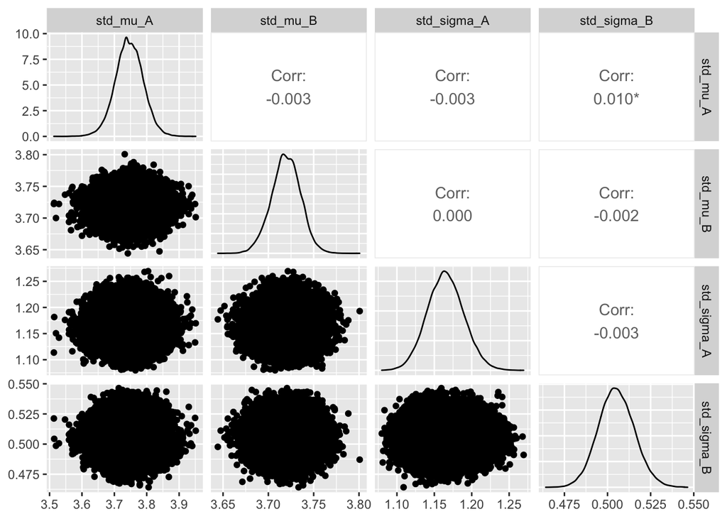

```r
ggpairs(chains_std_normal)
```

```r
# Censored normal
chains_cen_normal = as.data.frame(
  rbind(results_cen$mcmc[[1]], results_cen$mcmc[[2]], results_cen$mcmc[[3]])
)
colnames(chains_cen_normal) <- c("cen_mu_A","cen_mu_B","cen_sigma_A","cen_sigma_B")
kable(summary(results_cen), digits = 3, align = "c")
```

|  | Lower95 | Median | Upper95 | Mean | SD | Mode | MCerr | MC%ofSD | SSeff | AC.10 | psrf |
| --- | --- | --- | --- | --- | --- | --- | --- | --- | --- | --- | --- |
| mu.mu[1] | 3.838 | 3.946 | 4.052 | 3.947 | 0.054 | NA | 0.001 | 1.7 | 3563 | 0.109 | 1.000 |
| mu.mu[2] | 3.687 | 3.719 | 3.752 | 3.719 | 0.016 | NA | 0.000 | 2.5 | 1632 | 0.244 | 1.003 |
| sigma.mu[1] | 1.405 | 1.475 | 1.549 | 1.475 | 0.037 | NA | 0.000 | 1.0 | 9720 | 0.002 | 1.000 |
| sigma.mu[2] | 0.487 | 0.507 | 0.528 | 0.508 | 0.010 | NA | 0.000 | 0.7 | 17897 | 0.010 | 1.000 |

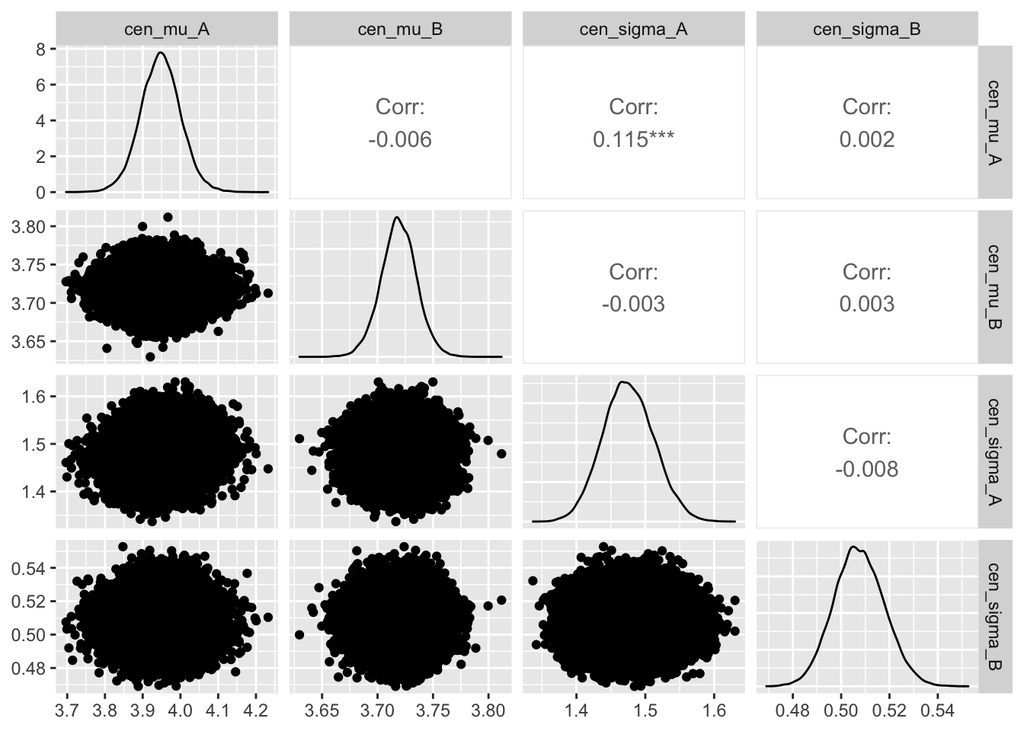

```r
ggpairs(chains_cen_normal)
```

### Group level density plots

#### Standard normal model

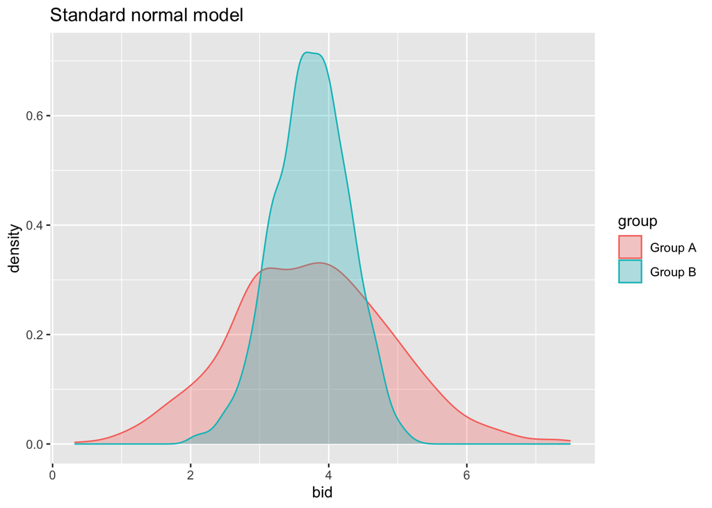

```r
mu_A_std = mean(chains_std_normal$std_mu_A)
sig_A_std = mean(chains_std_normal$std_sigma_A)
mu_B_std = mean(chains_std_normal$std_mu_B)
sig_B_std = mean(chains_std_normal$std_sigma_B)
sim_A_std = rnorm(1000, mean = mu_A_std, sd = sig_A_std)
sim_B_std = rnorm(1000, mean = mu_B_std, sd = sig_B_std)
df_std <- data.frame(
    bid=c(sim_A_std,sim_B_std),
    group=rep(c("Group A", "Group B"), each=1000 )
    )
ggplot(df_std, aes(x=bid, color=group, fill=group)) + geom_density(alpha=0.3) + ggtitle("Standard normal model")
```

#### Censored normal model

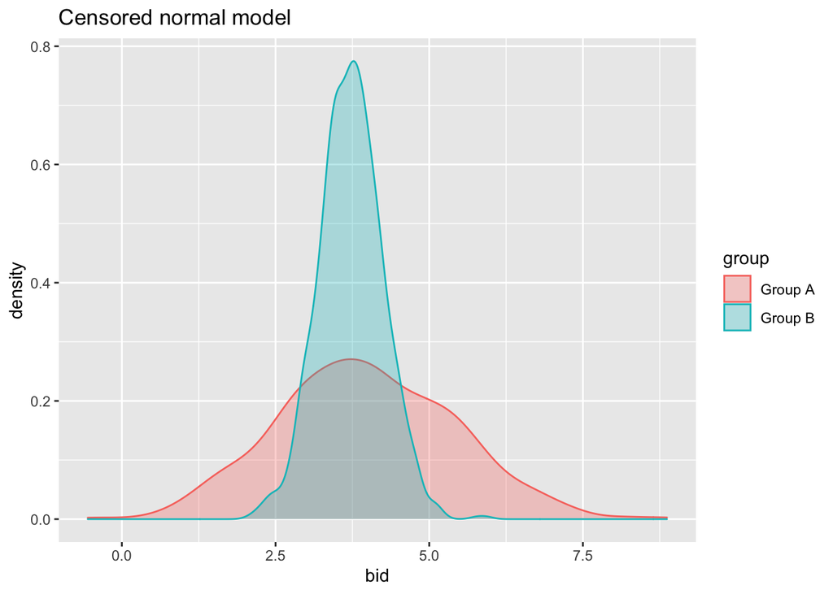

```r
mu_A_cen = mean(chains_cen_normal$cen_mu_A)
sig_A_cen = mean(chains_cen_normal$cen_sigma_A)
mu_B_cen = mean(chains_cen_normal$cen_mu_B)
sig_B_cen = mean(chains_cen_normal$cen_sigma_B)
sim_A_cen = rnorm(1000, mean = mu_A_cen, sd = sig_A_cen)
sim_B_cen = rnorm(1000, mean = mu_B_cen, sd = sig_B_cen)
df_cen <- data.frame(
    bid=c(sim_A_cen,sim_B_cen),
    group=rep(c("Group A", "Group B"), each=1000 )
    )
ggplot(df_cen, aes(x=bid, color=group, fill=group)) + geom_density(alpha=0.3) + ggtitle("Censored normal model")
```

### Difference between Group A and Group B

> *Answer:* For the Standard Normal model, there is no significant difference of mu between two groups, only significant difference of sigma. Whereas, there exist significant difference both mu and sigma between two groups. It appears that the censored normal model can better capture the difference between groups within censored data.

#### muA_standard - muB_standard

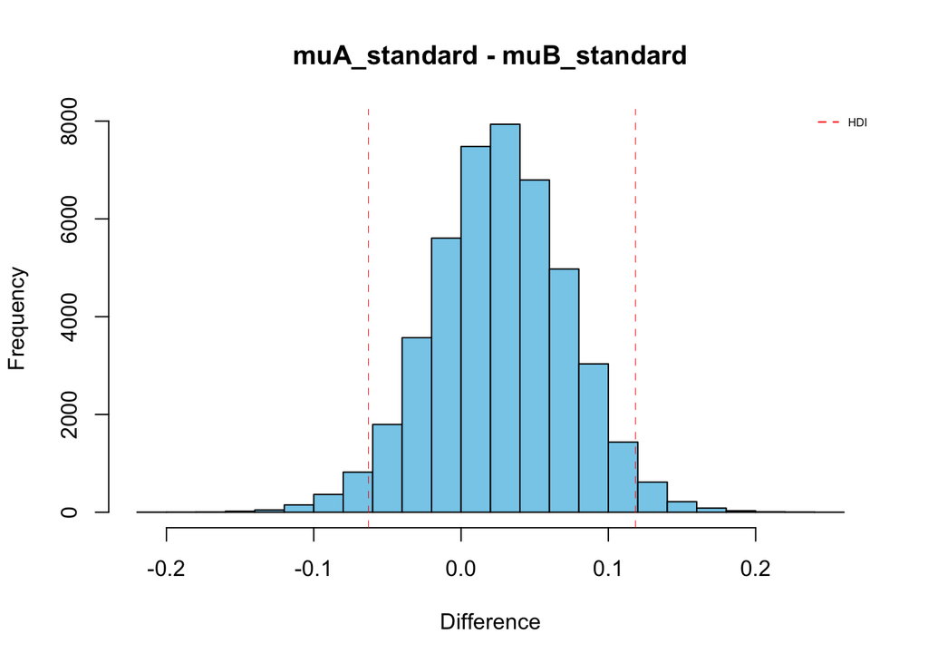

```r
mu_diff_std = chains_std_normal$std_mu_A - chains_std_normal$std_mu_B
hist(mu_diff_std, main = "muA_standard - muB_standard", xlab = "Difference", col = "skyblue")
abline(v = hdi(mu_diff_std), col = "red", lwd = .5, lty = "dashed")
legend("topright", legend = c("HDI"),
       col = c("red"), lty = c("dashed"),
       box.lty=0, cex = 0.5)
```

#### sigA_standard - sigB_standard

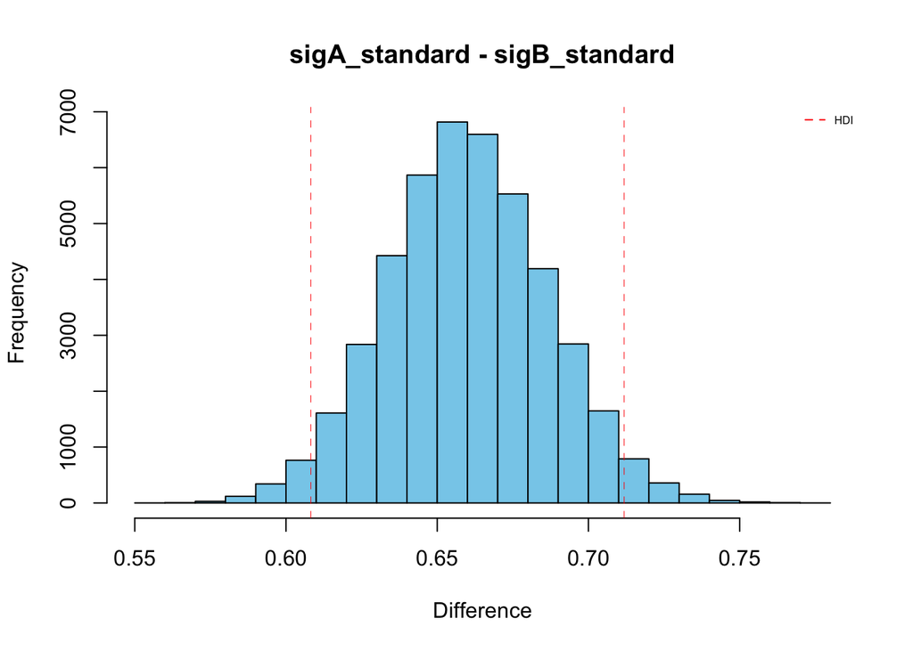

```r
sig_diff_std = chains_std_normal$std_sigma_A - chains_std_normal$std_sigma_B
hist(sig_diff_std, main = "sigA_standard - sigB_standard", xlab = "Difference", col = "skyblue")
abline(v = hdi(sig_diff_std), col = "red", lwd = .5, lty = "dashed")
legend("topright", legend = c("HDI"),
       col = c("red"), lty = c("dashed"),
       box.lty=0, cex = 0.5)
```

#### muA_censored - muB_censored

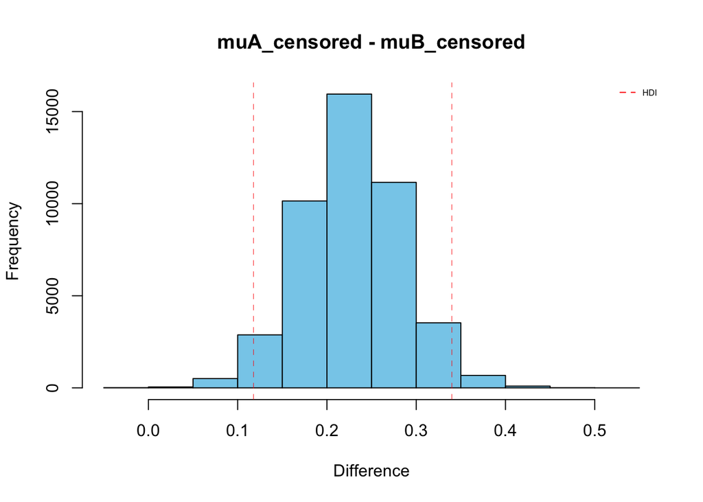

```r
mu_diff_cen = chains_cen_normal$cen_mu_A - chains_cen_normal$cen_mu_B
hist(mu_diff_cen, main = "muA_censored - muB_censored", xlab = "Difference", col = "skyblue")
abline(v = hdi(mu_diff_cen), col = "red", lwd = .5, lty = "dashed")
legend("topright", legend = c("HDI"),
       col = c("red"), lty = c("dashed"),
       box.lty=0, cex = 0.5)
```

#### sigA_censored - sigB_censored

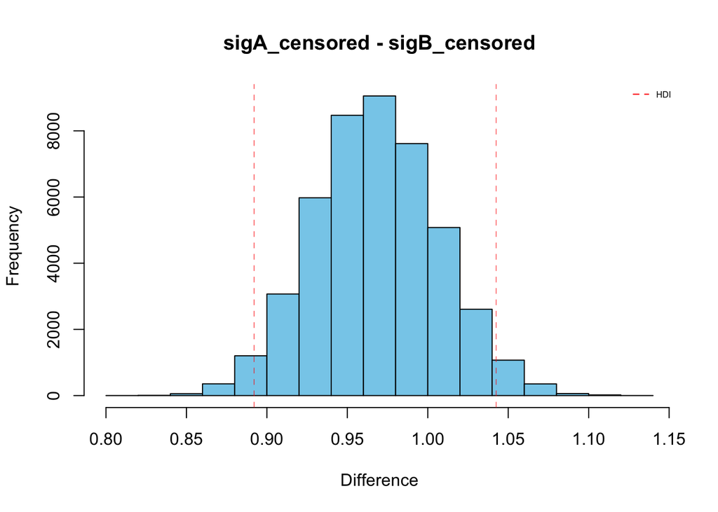

```r
sig_diff_cen = chains_cen_normal$cen_sigma_A - chains_cen_normal$cen_sigma_B
hist(sig_diff_cen, main = "sigA_censored - sigB_censored", xlab = "Difference", col = "skyblue")
abline(v = hdi(sig_diff_cen), col = "red", lwd = .5, lty = "dashed")
legend("topright", legend = c("HDI"),
       col = c("red"), lty = c("dashed"),
       box.lty=0, cex = 0.5)
```